# United Hopes Final Submission

```python
import seaborn as sns
import matplotlib.pyplot as plt
import re
from wordcloud import WordCloud
```

```python
train = pd.read_csv('./train.csv')
test = pd.read_csv('./evaluation.csv')
```

```python
train.head()
```

|  | storeId | url | additionalAttributes | breadcrumbs | label |
| --- | --- | --- | --- | --- | --- |
| 0 | 23 | http://www.walmart.com/ip/best-of-toto%3A-pian... | Contributed by=Toto;Format=Paperback;Number of... | books > art music & photography > music | books |
| 1 | NaN | NaN | NaN | best buy > computers & tablets > computer card... | rest |
| 2 | 23 | https://www.walmart.com/ip/34441317 | Performer=Cult Of Youth;Record Label=Vinyl;1.=... | music on cd or vinyl > rock music on cd or vin... | music |
| 3 | 26 | https://www.overstock.com/Books-Movies-Music-G... | Format=Paperback;Copyright Year=2000;Publisher... | books & media > books > cooking & food books >... | books |
| 4 | 22 | http://www.target.com/p/amore-version-ii/-/A-1... | Store Item Number (DPCI)=244-48-2721;Origin=Ma... | target > movies, music & books > music > class... | music |

# Exploratory Data Analysis

Let's see how the labels are distributed

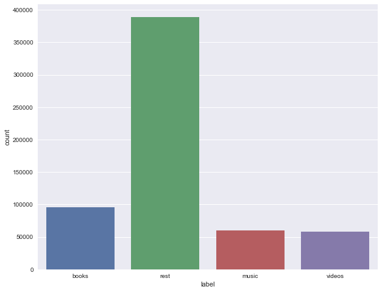

```
(' Distribution of each label : \n', rest      389250
books      95811
music      59996
videos     58144
Name: label, dtype: int64)
```

```python
plt.figure(figsize=(10,8))
sns.countplot(train.label)
plt.show()

print( " Distribution of each label : \n" , train.label.value_counts())
```

Looks like more items are in "rest" category

Lets now remove all the special characters in additional attributes and breadcrumbs

```python
def removeSpecialCharacters(x):
    try:
        text = re.sub('[^a-zA-Z0-9-_*.]', ' ', x)
        return text
    except:
        return ' '
```

```python
train.additionalAttributes = train.additionalAttributes.apply(lambda x : removeSpecialCharacters(x))
test.additionalAttributes = test.additionalAttributes.apply(lambda x : removeSpecialCharacters(x))
```

```python
train.breadcrumbs = train.breadcrumbs.apply(lambda x : removeSpecialCharacters(x))
test.breadcrumbs = test.breadcrumbs.apply(lambda x : removeSpecialCharacters(x))
```

```python
train.head()
```

|  | storeId | url | additionalAttributes | breadcrumbs | label |
| --- | --- | --- | --- | --- | --- |
| 0 | 23 | http://www.walmart.com/ip/best-of-toto%3A-pian... | Contributed by Toto Format Paperback Number of... | books art music photography music | books |
| 1 | NaN | NaN |  | best buy computers tablets computer card... | rest |
| 2 | 23 | https://www.walmart.com/ip/34441317 | Performer Cult Of Youth Record Label Vinyl 1. ... | music on cd or vinyl rock music on cd or vin... | music |
| 3 | 26 | https://www.overstock.com/Books-Movies-Music-G... | Format Paperback Copyright Year 2000 Publisher... | books media books cooking food books ... | books |
| 4 | 22 | http://www.target.com/p/amore-version-ii/-/A-1... | Store Item Number DPCI 244-48-2721 Origin Ma... | target movies music books music class... | music |

### Feature Engineering

Now lets create a new fetaure called description which is the combination of addditional attributes and breadcrumbs

```python
train['descsription'] = train.additionalAttributes + train.breadcrumbs
test['descsription'] = test.additionalAttributes + test.breadcrumbs
```

Now let's create 4 different dataframes and analyze them to see what kind of words are used majorly in each categories

```python
books_df = train[train.label == 'books']
music_df = train[train.label == 'music']
videos_df = train[train.label == 'videos']
rest_df = train[train.label == 'rest']
```

Lets use wordcloud and see what are the major words used in each category

[figure not shown]

```python
books_desc = books_df["descsription"].str.cat(sep = " ")
books_wordcloud = WordCloud().generate(books_desc)
plt.imshow(books_wordcloud, interpolation = "bilinear")
plt.axis("off")
plt.show()
```

[figure not shown]

```python
music_desc = music_df["descsription"].str.cat(sep = " ")
music_wordcloud = WordCloud().generate(music_desc)
plt.imshow(music_wordcloud, interpolation = "bilinear")
plt.axis("off")
plt.show()
```

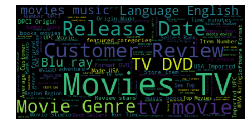

```python
videos_desc = videos_df["descsription"].str.cat(sep = " ")
videos_wordcloud = WordCloud().generate(videos_desc)
plt.imshow(videos_wordcloud, interpolation = "bilinear")
plt.axis("off")
plt.show()
```

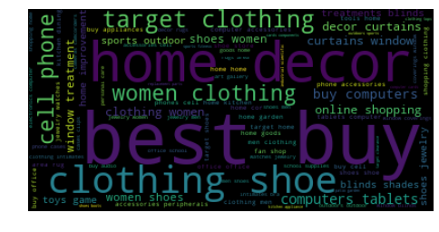

```python
rest_desc = rest_df["descsription"].str.cat(sep = " ")
rest_wordcloud = WordCloud().generate(rest_desc)
plt.imshow(rest_wordcloud, interpolation = "bilinear")
plt.axis("off")
plt.show()
```

Looks like all the categories have some key words which are used in most of the description Let's see how the word "Movies" are distributed in wach category

```python
print("Count of word 'Movies' in videos cat",videos_desc.count("Movies"))
print("Count of word 'Movies' in videos cat",books_desc.count("Movies"))
print("Count of word 'Movies' in videos cat",music_desc.count("Movies"))
print("Count of word 'Movies' in videos cat",rest_desc.count("Movies"))
```

```
("Count of word 'Movies' in videos cat", 47971)
("Count of word 'Movies' in videos cat", 157)
("Count of word 'Movies' in videos cat", 928)
("Count of word 'Movies' in videos cat", 0)
```

You can see how the word movies are distributed among different categories.

Seeing these data , I would go ahead with Bag of Words Approach with ngram range (1) , because I see that each category is heavily dependent on each of these key words

### Pre-processing

```python
from sklearn.feature_extraction.text import CountVectorizer
from sklearn.metrics import accuracy_score
from sklearn.model_selection import train_test_split
from sklearn.preprocessing import LabelEncoder
```

Let's first make the labels into numerical categories by using Label Encoder

```python
le = LabelEncoder()
le.fit(train.label)
train.label = le.transform(train.label)
```

```python
vect = CountVectorizer()
vect.fit(train.descsription)
X = vect.transform(train.descsription)
y= train.label
```

Using train_test_split for spliting the training data into test and train data

```python
X_train , X_test , y_train , y_test = train_test_split(X , y)
```

```python
print(X_train.shape)
print(X_test.shape)
```

```
(452400, 379731)
(150801, 379731)
```

### Model Selection

I am going to start with Linear models, because in my experience with considerable amount of data and features , linear model tend to be fast and give good results.

```python
from sklearn.linear_model import LogisticRegression
clf = LogisticRegression()
```

```python
clf.fit(X_train , y_train)
```

```
LogisticRegression(C=1.0, class_weight=None, dual=False, fit_intercept=True,
          intercept_scaling=1, max_iter=100, multi_class='ovr', n_jobs=1,
          penalty='l2', random_state=None, solver='liblinear', tol=0.0001,
          verbose=0, warm_start=False)
```

```python
y_pred = clf.predict(X_test)
```

```python
print("Accuracy score : - " , accuracy_score(y_pred , y_test))
```

```
('Accuracy score : - ', 0.99984748111749921)
```

Still there is a small chance that the X_test generated was perfectly fit for the portion of test set created. To verify that no overfitting has happened in the model , I will use cross_val_score

### Cross - Validation

```python
from sklearn.cross_validation import cross_val_score
scores = cross_val_score(clf , X_train , y_train)
```

```python
print (np.mean(scores))
```

```
0.999847480062
```

### Parameter Tuning

Let's see if we can improve the score by tuning the parameters

```python
from sklearn.grid_search import GridSearchCV
params = { 'C' : [0.1 , 1 , 10]}
grid =  GridSearchCV(clf , params)
grid.fit(X_train , y_train)
```

```
GridSearchCV(cv=None, error_score='raise',
       estimator=LogisticRegression(C=1.0, class_weight=None, dual=False, fit_intercept=True,
          intercept_scaling=1, max_iter=100, multi_class='ovr', n_jobs=1,
          penalty='l2', random_state=None, solver='liblinear', tol=0.0001,
          verbose=0, warm_start=False),
       fit_params={}, iid=True, n_jobs=1, param_grid={'C': [0.1, 1, 10]},
       pre_dispatch='2*n_jobs', refit=True, scoring=None, verbose=0)
```

```python
print " Best Score ", grid.best_score_
print " Best params", grid.best_params_
```

```
 Best Score  0.999874005305
 Best params {'C': 10}
```

### Final Model

```python
clf = LogisticRegression(C=10)
clf.fit(X_train , y_train)
```

```
LogisticRegression(C=10, class_weight=None, dual=False, fit_intercept=True,
          intercept_scaling=1, max_iter=100, multi_class='ovr', n_jobs=1,
          penalty='l2', random_state=None, solver='liblinear', tol=0.0001,
          verbose=0, warm_start=False)
```

```python
X_test = vect.transform(test.descsription)
y_final = clf.predict(X_test)
```

```python
test['label'] = y_final
```

```python
test['label'] = le.inverse_transform(y_final)
```

```python
test
```

|  | storeId | url | additionalAttributes | breadcrumbs | id | descsription | label |
| --- | --- | --- | --- | --- | --- | --- | --- |
| 0 | NaN | NaN |  | baby products bathing skin care washclot... | 8589934592 | baby products bathing skin care washclo... | rest |
| 1 | NaN | NaN |  | online shopping home garden art gal... | 8589934593 | online shopping home garden art ga... | rest |
| 2 | NaN | NaN |  | home goods kitchen dining table linens ... | 8589934594 | home goods kitchen dining table linens ... | rest |
| 3 | NaN | NaN |  | 11320 | 8589934595 | 11320 | rest |
| 4 | NaN | NaN |  | tools home improvement kitchen bath fixt... | 8589934596 | tools home improvement kitchen bath fix... | rest |
| 5 | NaN | NaN |  | best buy cameras camcorders digital came... | 8589934597 | best buy cameras camcorders digital cam... | rest |
| 6 | NaN | NaN |  | clothing boys boys jackets outerwear | 8589934598 | clothing boys boys jackets outerwear | rest |
| 7 | NaN | NaN |  | target clothing women s clothing ... | 8589934599 | target clothing women s clothing ... | rest |
| 8 | NaN | NaN |  | target sports fitness outdoors fan shop... | 8589934600 | target sports fitness outdoors fan sho... | rest |
| 9 | NaN | NaN |  | toys games | 8589934601 | toys games | rest |
| 10 | NaN | NaN |  | target shoes women s shoes sandals fli... | 8589934602 | target shoes women s shoes sandals fl... | rest |
| 11 | NaN | NaN |  | online shopping home garden art gal... | 8589934603 | online shopping home garden art ga... | rest |
| 12 | NaN | NaN |  | home decor curtains window covering... | 8589934604 | home decor curtains window coverin... | rest |
| 13 | NaN | NaN |  | best buy health fitness beauty personal ... | 8589934605 | best buy health fitness beauty personal... | rest |
| 14 | NaN | NaN |  | patio garden gardening lawn care ... | 8589934606 | patio garden gardening lawn care ... | rest |
| 15 | NaN | NaN |  | office products office school supplies p... | 8589934607 | office products office school supplies ... | rest |
| 16 | NaN | NaN |  | target clearance clothing accessories ... | 8589934608 | target clearance clothing accessories ... | rest |
| 17 | NaN | NaN |  | best buy cell phones cell phone accessorie... | 8589934609 | best buy cell phones cell phone accessori... | rest |
| 18 | NaN | NaN |  | home improvement hardware cabinet hardware... | 8589934610 | home improvement hardware cabinet hardwar... | rest |
| 19 | NaN | NaN |  | best buy computers tablets ipad tablet... | 8589934611 | best buy computers tablets ipad table... | rest |
| 20 | NaN | NaN |  | clothing shoes accessories hats women ... | 8589934612 | clothing shoes accessories hats women... | rest |
| 21 | NaN | NaN |  | beauty fragrances all fragrances | 8589934613 | beauty fragrances all fragrances | rest |
| 22 | 26 | https://www.overstock.com/Books-Movies-Music-G... | Format Paperback Copyright Year 2013 Series Na... | books media books science books genera... | 8589934614 | Format Paperback Copyright Year 2013 Series Na... | books |
| 23 | NaN | NaN |  | jewelry watches jewelry wedding rin... | 8589934615 | jewelry watches jewelry wedding ri... | rest |
| 24 | NaN | NaN |  | online shopping clothing shoes shoe... | 8589934616 | online shopping clothing shoes sho... | rest |
| 25 | NaN | NaN |  | target home home decor rugs area rugs | 8589934617 | target home home decor rugs area rugs | rest |
| 26 | NaN | NaN |  | tools home improvement electrical breake... | 8589934618 | tools home improvement electrical break... | rest |
| 27 | NaN | NaN |  | health household vitamins dietary supple... | 8589934619 | health household vitamins dietary suppl... | rest |
| 28 | NaN | NaN |  | home improvement bathroom renovation bathr... | 8589934620 | home improvement bathroom renovation bath... | rest |
| 29 | 24 | https://www.amazon.com/dp/1520591861?psc=1 | author Visit Amazon s R.S. Mollison-Read Pages... | books literature fiction genre fiction ... | 8589934621 | author Visit Amazon s R.S. Mollison-Read Pages... | books |
| ... | ... | ... | ... | ... | ... | ... | ... |
| 442011 | NaN | NaN |  | target shoes women s shoes heels pumps | 1099511629680 | target shoes women s shoes heels pumps | rest |
| 442012 | NaN | NaN |  | home decor curtains window treatmen... | 1099511629681 | home decor curtains window treatme... | rest |
| 442013 | NaN | NaN |  | 11320 | 1099511629682 | 11320 | rest |
| 442014 | NaN | NaN |  | beauty personal care makeup face blush | 1099511629683 | beauty personal care makeup face blush | rest |
| 442015 | NaN | NaN |  | best buy computers tablets ipad tablet... | 1099511629684 | best buy computers tablets ipad table... | rest |
| 442016 | NaN | NaN |  | best buy audio headphones all headphones | 1099511629685 | best buy audio headphones all headphones | rest |
| 442017 | NaN | NaN |  | toys games | 1099511629686 | toys games | rest |
| 442018 | NaN | NaN |  | patio garden gardening lawn care ... | 1099511629687 | patio garden gardening lawn care ... | rest |
| 442019 | NaN | NaN |  | best buy cell phones cell phone accessorie... | 1099511629688 | best buy cell phones cell phone accessori... | rest |
| 442020 | NaN | NaN |  | home kitchen home d cor picture frames ... | 1099511629689 | home kitchen home d cor picture frames... | rest |
| 442021 | NaN | NaN |  | target home bedding sheets pillowcases | 1099511629690 | target home bedding sheets pillowcases | rest |
| 442022 | NaN | NaN |  | online shopping home garden art gal... | 1099511629691 | online shopping home garden art ga... | rest |
| 442023 | NaN | NaN |  | home decor curtains window treatmen... | 1099511629692 | home decor curtains window treatme... | rest |
| 442024 | NaN | NaN |  | best buy office office school supplies ... | 1099511629693 | best buy office office school supplies ... | rest |
| 442025 | NaN | NaN |  | electronics computer hardware software ... | 1099511629694 | electronics computer hardware software... | rest |
| 442026 | NaN | NaN |  | toys games learning education basic ... | 1099511629695 | toys games learning education basic ... | rest |
| 442027 | NaN | NaN |  | best buy computers tablets computer acce... | 1099511629696 | best buy computers tablets computer acc... | rest |
| 442028 | NaN | NaN |  | best buy computers tablets computer card... | 1099511629697 | best buy computers tablets computer car... | rest |
| 442029 | NaN | NaN |  | target clearance clothing accessories cl... | 1099511629698 | target clearance clothing accessories c... | rest |
| 442030 | NaN | NaN |  | toys games | 1099511629699 | toys games | rest |
| 442031 | NaN | NaN |  | home kitchen dining kitchen storage or... | 1099511629700 | home kitchen dining kitchen storage o... | rest |
| 442032 | NaN | NaN |  | patio garden grills outdoor cooking el... | 1099511629701 | patio garden grills outdoor cooking e... | rest |
| 442033 | NaN | NaN |  | tools home improvement lighting ceiling ... | 1099511629702 | tools home improvement lighting ceiling... | rest |
| 442034 | 22 | https://www.target.com/p/spin-cycle-spin-cycle... | Store Item Number DPCI 244-52-2134 Origin Ma... | target movies music books music jazz | 1099511629703 | Store Item Number DPCI 244-52-2134 Origin Ma... | music |
| 442035 | 23 | https://www.walmart.com/ip/Hell-Fighters/35108551 | Performer Lieut. Jim Europe s 369th Infantry B... | music on cd or vinyl jazz music on cd or vin... | 1099511629704 | Performer Lieut. Jim Europe s 369th Infantry B... | music |
| 442036 | NaN | NaN |  | clothing shoes shoes women s shoes wedges | 1099511629705 | clothing shoes shoes women s shoes we... | rest |
| 442037 | NaN | NaN |  | home decor art wall decor canva... | 1099511629706 | home decor art wall decor canv... | rest |
| 442038 | NaN | NaN |  | grocery gourmet food snack foods cookies... | 1099511629707 | grocery gourmet food snack foods cookie... | rest |
| 442039 | NaN | NaN |  | food snacks cookies chips nuts trail m... | 1099511629708 | food snacks cookies chips nuts trail ... | rest |
| 442040 | 2627 | http://www.barnesandnoble.com/w/oh-flanders-fr... | Release Date 05 16 2000 UPC 0636943451625 La... | music | 1099511629709 | Release Date 05 16 2000 UPC 0636943451625 La... | music |

442041 rows × 7 columns

```python
test.to_csv('./submissions.csv' , index=False)
```